# ArabianNights

2022-12-07

# Textmining in The Arabian Nights

To create my project I need different packages. Below you can see then ones I have used:

```r
knitr::opts_chunk$set(echo = TRUE)

library(tidyverse)
library(here)
```

```r
library(tidytext)
library(textdata)
library(ggwordcloud)
library(gutenbergr)
library(igraph)
library(ggraph)
library(ggplot2)
```

I found the gutenbergr package installation guide here: https://www.rdocumentation.org/packages/gutenbergr/versions/0.2.1 I found the ggraph package installation guide here: https://www.rdocumentation.org/packages/ggraph/versions/0.1.1

### Download data

I then use the gutenbergr package to first locate the gutenberg_id and then download the 10 volumes of Arabian Nights. I do that for each of the volumes seperately:

```r
gutenberg_works(title == "A Plain and Literal Translation of the Arabian Nights Entertainments, Now Entituled the Book of the Thousand Nights and a Night, Volume 01 (of 17)")
```

```
## # A tibble: 1 × 8
##   gutenberg_id title    author gutenberg_autho… language gutenberg_books… rights
##          <int> <chr>    <chr>             <int> <chr>    <chr>            <chr>
## 1        51252 A Plain… <NA>                 NA en       <NA>             Publi…
## # … with 1 more variable: has_text <lgl>
```

```r
arabian_nights_vol1 <- gutenberg_download(51252)
```

```
## Determining mirror for Project Gutenberg from https://www.gutenberg.org/robot/harvest
```

```
## Using mirror http://aleph.gutenberg.org
```

```r
gutenberg_works(title == "A Plain and Literal Translation of the Arabian Nights Entertainments, Now Entituled the Book of the Thousand Nights and a Night, Volume 02 (of 17)")
```

```
## # A tibble: 1 × 8
##   gutenberg_id title    author gutenberg_autho… language gutenberg_books… rights
##          <int> <chr>    <chr>             <int> <chr>    <chr>            <chr>
## 1        51775 A Plain… <NA>                 NA en       <NA>             Publi…
## # … with 1 more variable: has_text <lgl>
```

```r
arabian_nights_vol2 <- gutenberg_download(51775)
```

```r
gutenberg_works(title == "A Plain and Literal Translation of the Arabian Nights Entertainments, Now Entituled the Book of the Thousand Nights and a Night, Volume 03 (of 17)")
```

```
## # A tibble: 1 × 8
##   gutenberg_id title    author gutenberg_autho… language gutenberg_books… rights
##          <int> <chr>    <chr>             <int> <chr>    <chr>            <chr>
## 1        52564 A Plain… <NA>                 NA en       <NA>             Publi…
## # … with 1 more variable: has_text <lgl>
```

```r
arabian_nights_vol3 <- gutenberg_download(52564)
```

```r
gutenberg_works(title == "A Plain and Literal Translation of the Arabian Nights Entertainments, Now Entituled the Book of the Thousand Nights and a Night, Volume 04 (of 17)")
```

```
## # A tibble: 1 × 8
##   gutenberg_id title    author gutenberg_autho… language gutenberg_books… rights
##          <int> <chr>    <chr>             <int> <chr>    <chr>            <chr>
## 1        53254 A Plain… <NA>                 NA en       <NA>             Publi…
## # … with 1 more variable: has_text <lgl>
```

```r
arabian_nights_vol4 <- gutenberg_download(53254)
```

```r
gutenberg_works(title == "A Plain and Literal Translation of the Arabian Nights Entertainments, Now Entituled the Book of the Thousand Nights and a Night, Volume 05 (of 17)")
```

```
## # A tibble: 1 × 8
##   gutenberg_id title    author gutenberg_autho… language gutenberg_books… rights
##          <int> <chr>    <chr>             <int> <chr>    <chr>            <chr>
## 1        54257 A Plain… <NA>                 NA en       <NA>             Publi…
## # … with 1 more variable: has_text <lgl>
```

```r
arabian_nights_vol5 <- gutenberg_download(54257)
```

```r
gutenberg_works(title == "A Plain and Literal Translation of the Arabian Nights Entertainments, Now Entituled the Book of the Thousand Nights and a Night, Volume 06 (of 17)")
```

```
## # A tibble: 1 × 8
##   gutenberg_id title    author gutenberg_autho… language gutenberg_books… rights
##          <int> <chr>    <chr>             <int> <chr>    <chr>            <chr>
## 1        54525 A Plain… <NA>                 NA en       <NA>             Publi…
## # … with 1 more variable: has_text <lgl>
```

```r
arabian_nights_vol6 <- gutenberg_download(54525)
```

```r
gutenberg_works(title == "A Plain and Literal Translation of the Arabian Nights Entertainments, Now Entituled the Book of the Thousand Nights and a Night, Volume 07 (of 17)")
```

```
## # A tibble: 1 × 8
##   gutenberg_id title    author gutenberg_autho… language gutenberg_books… rights
##          <int> <chr>    <chr>             <int> <chr>    <chr>            <chr>
## 1        54778 A Plain… <NA>                 NA en       <NA>             Publi…
## # … with 1 more variable: has_text <lgl>
```

```r
arabian_nights_vol7 <- gutenberg_download(54778)
```

```r
gutenberg_works(title == "A Plain and Literal Translation of the Arabian Nights Entertainments, Now Entituled the Book of the Thousand Nights and a Night Volume 08 (of 17)")
```

```
## # A tibble: 1 × 8
##   gutenberg_id title    author gutenberg_autho… language gutenberg_books… rights
##          <int> <chr>    <chr>             <int> <chr>    <chr>            <chr>
## 1        55091 A Plain… <NA>                 NA en       <NA>             Publi…
## # … with 1 more variable: has_text <lgl>
```

```r
arabian_nights_vol8 <- gutenberg_download(55091)
```

```r
gutenberg_works(title == "A Plain and Literal Translation of the Arabian Nights Entertainments, Now Entituled the Book of the Thousand Nights and a Night, Volume 09 (of 17)")
```

```
## # A tibble: 1 × 8
##   gutenberg_id title    author gutenberg_autho… language gutenberg_books… rights
##          <int> <chr>    <chr>             <int> <chr>    <chr>            <chr>
## 1        55587 A Plain… <NA>                 NA en       <NA>             Publi…
## # … with 1 more variable: has_text <lgl>
```

```r
arabian_nights_vol9 <- gutenberg_download(55587)
```

```r
gutenberg_works(title == "A Plain and Literal Translation of the Arabian Nights Entertainments, Now Entituled the Book of the Thousand Nights and a Night, Volume 10 (of 17)")
```

```
## # A tibble: 1 × 8
##   gutenberg_id title    author gutenberg_autho… language gutenberg_books… rights
##          <int> <chr>    <chr>             <int> <chr>    <chr>            <chr>
## 1        58360 A Plain… <NA>                 NA en       <NA>             Publi…
## # … with 1 more variable: has_text <lgl>
```

```r
arabian_nights_vol10 <- gutenberg_download(58360)
```

### Prep Data

Then I combine all the ten volumes in to one single dataframe:

```r
an_df <- do.call("rbind", list(arabian_nights_vol1, arabian_nights_vol2, arabian_nights_vol3, arabian_nights_vol4, arabian_nights_vol5, arabian_nights_vol6, arabian_nights_vol7, arabian_nights_vol8, arabian_nights_vol9, arabian_nights_vol10))
```

The code I have used to do that, I have found here: https://medium.com/coinmonks/merging-multiple-dataframes-in-r-72629c4632a3

In the dataframe there is a lot of text, that aren’t part of the stories that are Arabian Nights. To get the most accurate result I’ll try to trim most of the excessive text away, but it is has to pick out in such a large text. I’ll be doing the trimming by cutting out specific rows from my data.frame:

```r
an_df_tidy <- an_df[-c(1:780, 1545:1844, 2268:2437, 3866:4536, 7995:9555, 9846:9913, 11869:12845, 15962:18806, 151902:189676, 148281:150158, 131077:133627, 114421:116373, 97810:99392, 83707:85877, 65031:66536, 48903:51794),]
```

The code I have used to remove rows, I have found here:https://sparkbyexamples.com/r-programming/drop-dataframe-rows-in-r/

I’m interested in playing around with the frequency of words in Arabian Nights. The first thing I have to do, to be able to look at that, is to tokenize the dataframe, so every word gets it’s own row in a dataframe:

```r
an_tokens <- an_df_tidy %>%
  unnest_tokens(word, text)
```

Now I can count how many there are of each word, and sort them after the most frequent one:

```r
an_wc <- an_tokens %>%
  count(word) %>%
  arrange(-n)
```

Then I can add the stopwords list:

```r
an_stop <- an_tokens %>%
  anti_join(stop_words)
```

Then I count and sort the words again:

```r
an_swc <- an_stop %>%
  count(word) %>%
  arrange(-n)
```

Because the book was written in the 19th century, there are a lot of old words, that is not on the stopword list, but should still be removed for practicality’s sake. Therefore I’ll make my own stopword list, to also add to the dataframe:

```r
my_stop_words <- data.frame(word = c("thou", "thee", "thy", "till", "hath", "quoth", "footnote", "answered", "replied", "set", "al", "arab", "ye"))
```

Now I load the newly created stopword list into the dataframe, that already has the preexisting one:

```r
an_stop_new <- an_stop %>%
  anti_join(my_stop_words)
```

Then I count and sort the words again:

```r
an_twc <- an_stop_new %>%
  count(word) %>%
  arrange(-n)
```

### Wordcloud

I will now make a wordcloud with the most frequent words in Arabian Nights. The first thing I want to do is to filter out any numbers from the text, by doing this:

```r
an_no_numeric <- an_stop_new %>%
  filter(is.na(as.numeric(word)))
length(unique(an_no_numeric$word))
```

```
## [1] 33123
```

By using this code I can see that there are over 33.000 unique words in Arabian Nights. That is too many to fit into one wordcloud, so I want to limit the number of words in the wordcloud to 100.

I limit the number of words in the wordcloud by doing this:

```r
an_top100 <- an_no_numeric %>%
  count(word) %>%
  arrange(-n) %>%
  head(100)
```

Now I make a wordcloud based on the new dataframe, I just created, with only the 100 most frequent words in Arabian Nights:

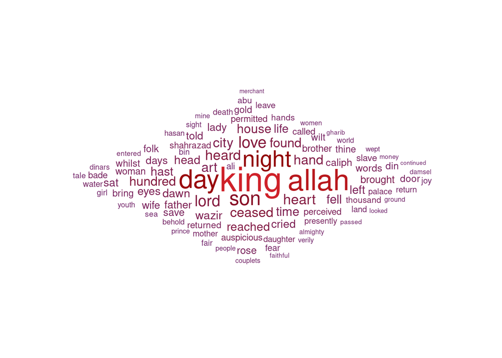

```r
ggplot(data = an_top100, aes(label = word, size = n)) +
  geom_text_wordcloud_area(aes(color = n), shape = "diamond") +
  scale_size_area(max_size = 12) +
  scale_color_gradientn(colors = c("#72286F","darkred","#CF2129")) +
  theme_minimal()
```

I can then see that the most frequent word is “king”, but it is worth noting that words like “love” and “wife” also is on the list of the 100 most frequent words in Arabian Nights, and that is words that would be interesting to take a little closer look at.

### Sentiment Analysis

First I’ll do a sentiment analysis on Arabian Nights. My analysis will focus on the “nrc” lexicon, so I have to load the lexicon:

```r
get_sentiments(lexicon = "nrc")
```

```
## # A tibble: 13,872 × 2
##    word        sentiment
##    <chr>       <chr>
##  1 abacus      trust
##  2 abandon     fear
##  3 abandon     negative
##  4 abandon     sadness
##  5 abandoned   anger
##  6 abandoned   fear
##  7 abandoned   negative
##  8 abandoned   sadness
##  9 abandonment anger
## 10 abandonment fear
## # … with 13,862 more rows
```

**Citation for NRC lexicon**: Crowdsourcing a Word-Emotion Association Lexicon, Saif Mohammad and Peter Turney, Computational Intelligence, 29 (3), 436-465, 2013.

Then I’ll create a new dataframe where I add the lexicon to my existing dataframe:

```r
an_nrc <- an_stop_new %>%
  inner_join(get_sentiments("nrc"))
```

By binding the lexicon to the dataframe, that’ll exclude words, that don’t have a “sentiment” value. It is smart to just have a look at which words it excludes:

```r
an_exclude <- an_stop_new %>%
  anti_join(get_sentiments("nrc"))
an_exclude_n <- an_exclude %>%
  count(word, sort = TRUE)

head(an_exclude_n)
```

```
## # A tibble: 6 × 2
##   word       n
##   <chr>  <int>
## 1 allah   4219
## 2 day     3199
## 3 night   2962
## 4 son     2102
## 5 ceased  1641
## 6 heard   1595
```

It is interesting that a word like “allah” has been excluded, you would think that it has a “sentiment” value.

Now I count how many words fit into each of the 10 different “sentiment” categories, and then I plot them:

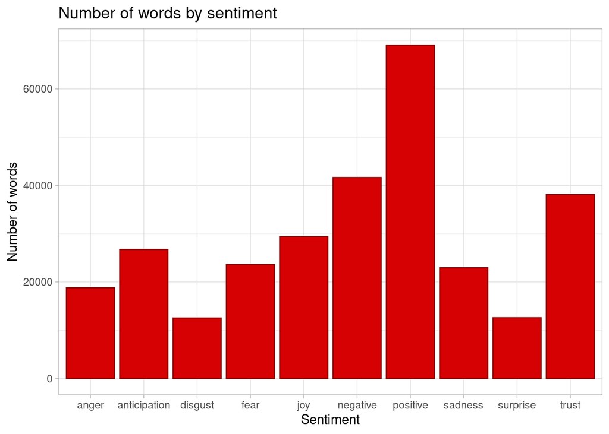

```r
an_nrc_n <- an_nrc %>%
  count(sentiment, sort = TRUE)

ggplot(data = an_nrc_n, aes(x = sentiment, y = n)) +
  geom_bar(stat = "identity", color = "darkred", fill = "#D60103") +
  theme_light() +
  ggtitle("Number of words by sentiment") +
  xlab("Sentiment") + ylab("Number of words")
```

From this I can see that there are a lot of words that are of a positive “sentiment”.

Since I’m interested in looking at words like “love” and others that are related to it. I’m first going to find out which “sentiment” categories that the word “love” is in:

```r
love <- get_sentiments(lexicon = "nrc") %>%
  filter(word == "love", ignore_case = TRUE)

love
```

```
## # A tibble: 2 × 2
##   word  sentiment
##   <chr> <chr>
## 1 love  joy
## 2 love  positive
```

I can now see that the word “love” is both in the category of “joy” and “positive”. Therefore I want to take a closer look at those two categories, to see which other words are in them, and if they are relevant for my project. I’ll focus on “joy” first:

The first step is to create a new dataframe that only contains the words in the “joy” category:

```r
nrc_joy <- get_sentiments("nrc") %>%
  filter(sentiment == "joy")
```

Then I count the words, and sort them by most frequent. I also limit them to only the 15 most frequent. I then plot thos 15 words, and order them by frequency:

```r
nrc_joy_sort <- an_stop_new %>%
  inner_join(nrc_joy) %>%
  count(word, sort = TRUE) %>%
  head(15)
```

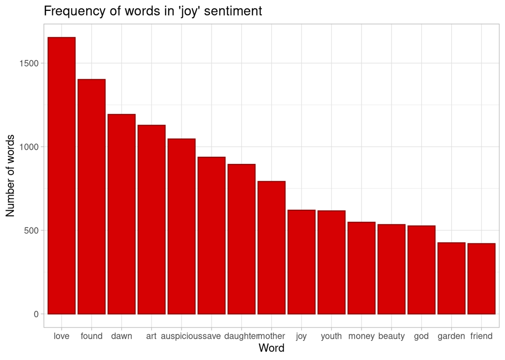

```r
ggplot(data = nrc_joy_sort, aes(x = reorder(word, -n), y = n)) +
  geom_bar(stat = "identity", color = "darkred", fill = "#D60103") +
  theme_light() +
  ggtitle("Frequency of words in 'joy' sentiment") +
  xlab("Word") + ylab("Number of words")
```

It’s interesting to see, that apart from “love”, words like “youth” and “beauty” are also relatively frequent.

Now I’ll do the same for the category “positive”. I first create a new dataframe:

```r
nrc_positive <- get_sentiments("nrc") %>%
  filter(sentiment == "positive")
```

Then I count the words, and sort them by most frequent. I also limit them to only the 15 most frequent. I then plot those 15 words, and order them by frequency:

```r
nrc_positive_sort <- an_stop_new %>%
  inner_join(nrc_positive) %>%
  count(word, sort = TRUE) %>%
  head(15)
```

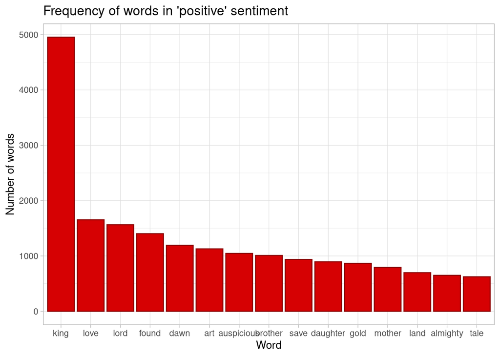

```r
ggplot(data = nrc_positive_sort, aes(x = reorder(word, -n), y = n)) +
  geom_bar(stat = "identity", color = "darkred", fill = "#D60103") +
  theme_light() +
  ggtitle("Frequency of words in 'positive' sentiment") +
  xlab("Word") + ylab("Number of words")
```

Here we can see, that the word “king” is much more frequent than any of the other positive words.

### Word frequency by night

Now I’ll take a look at figuring out more precisely where words I find relevant for my paper is the most frequent. Then I can hopefully use it, to find the most ideal tales, to read. In that way I’ll be able to save my self some time:

First up I want to split the book up into smaller sections, to get the most precise results, when I look for where in Arabian Nights I can find a high frequency of words. I would have liked to split it by the separate tales, but have unfortunately not been able to come up with a regex that captured all the tales. I have instead been able to split it by the separate nights, this way:

```r
an_df_tidy %>%
  mutate(
    linenumber = row_number()) %>%
  filter(str_detect(text, regex("Now when it w*as the .+ Night", ignore_case = TRUE)))
```

```
## # A tibble: 1,000 × 3
##    gutenberg_id text                                                  linenumber
##           <int> <chr>                                                      <int>
##  1        51252 "                    Now when it was the Second Nigh…        923
##  2        51252 "                    Now when it was the Third Night…       1174
##  3        51252 "                    Now when it was the Fourth Nigh…       1388
##  4        51252 "                    Now when it was the Fifth Night…       1598
##  5        51252 "                    Now when it was the Sixth Night…       1947
##  6        51252 "                   Now when it was the Seventh Nigh…       2084
##  7        51252 "                    Now when it was the Eighth Nigh…       2351
##  8        51252 "                    Now when it was the Ninth Night…       2553
##  9        51252 "                    Now when it was the Tenth Night…       2975
## 10        51252 "                   Now when it was the Eleventh Nig…       3337
## # … with 990 more rows
```

When you run this, you should get a tibble, that has a 1000 rows. I can only capture 1000 nights, since the first night isn’t written out, so it is as close as I can get.

I now make it into a new dataframe, where each night has a number associated with it:

```r
tidy_stories <- an_df_tidy %>%
  mutate(linenumber = row_number(), chapter = cumsum(str_detect(text, regex("Now when it w*as the .+ Night", ignore_case = TRUE))))
```

It is important to note that the first story has the number “0” and the second story has the number “1” and so on. Therefore to get the correct night, you have to take the number you get in the code, and subtract 1 from it. When I find out which nights the words are most frequent in, then I can look up which story the night belongs to, and then read it. I can find a list over stories, with night numbers here: https://en.wikipedia.org/wiki/List_of_stories_within_One_Thousand_and_One_Nights

```r
tidy_love <- tidy_stories %>%
  filter(str_detect(text, regex("love", ignore_case = TRUE))) %>%
  count(chapter, sort = TRUE) %>%
  head(20)
```

Then I plot it:

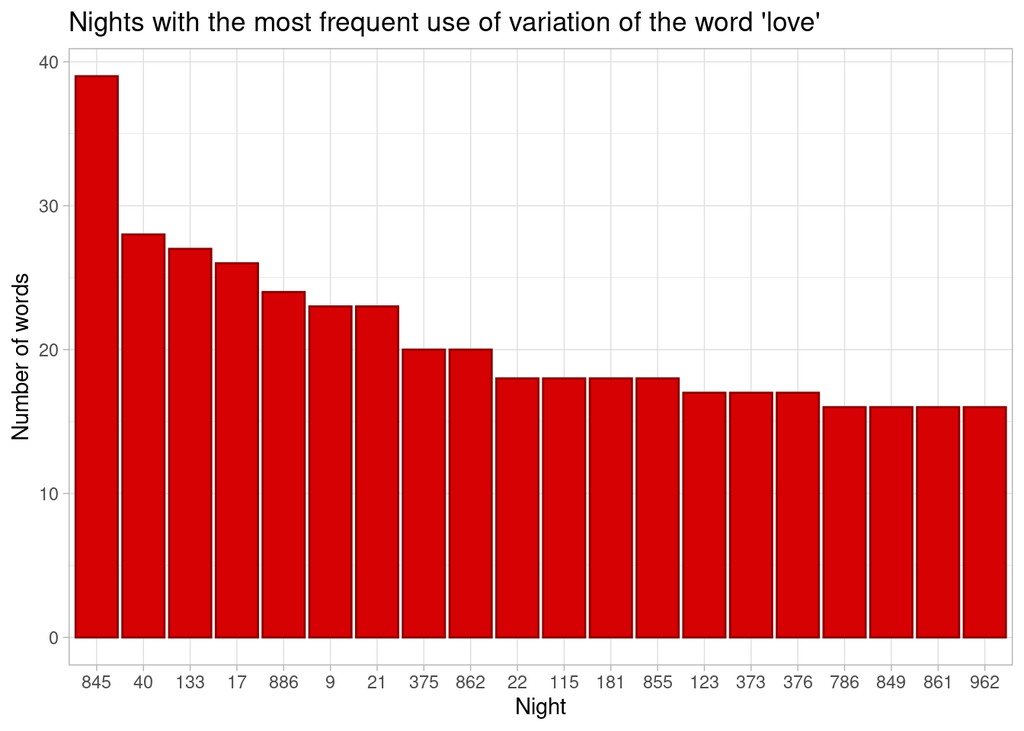

```r
tidy_love %>%
  ggplot(aes(x = reorder(chapter, -n), y = n)) +
  geom_bar(stat = "identity", color = "darkred", fill = "#D60103") +
  theme_light() +
  ggtitle("Nights with the most frequent use of variation of the word 'love'") +
  xlab("Night") + ylab("Number of words")
```

Here I can see that night 844, is the night where there is the most frequent use of the word “love”. That is the tale of Khalifah The Fisherman Of Baghdad.

Another word, or variations of a word, that i would like to have a look at is “marr”. So I’m just going to repeat the two previous steps and replace “love” with “marr”

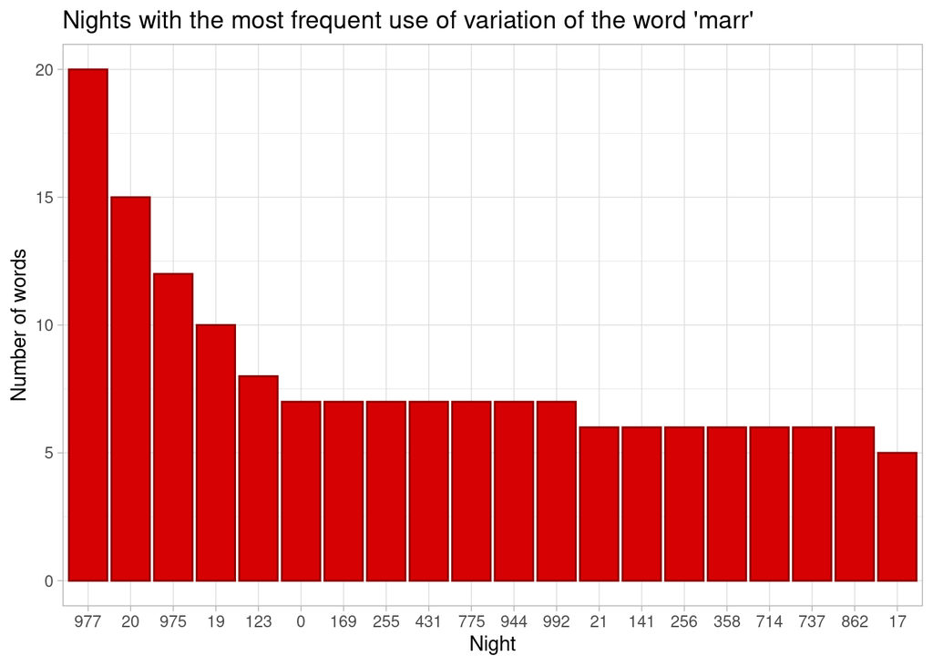

```r
tidy_marr <- tidy_stories %>%
  filter(str_detect(text, regex("marr", ignore_case = TRUE))) %>%
  count(chapter, sort = TRUE) %>%
  head(20)

tidy_marr %>%
  ggplot(aes(x = reorder(chapter, -n), y = n)) +
  geom_bar(stat = "identity", color = "darkred", fill = "#D60103") +
  theme_light() +
  ggtitle("Nights with the most frequent use of variation of the word 'marr'") +
  xlab("Night") + ylab("Number of words")
```

### Term frequency analysis

This is of course one way to look at word frequency, but it would be more ideal to look at the number of one specific word, in relation to the total number of words in one night. To do that i will have to do a term frequency analysis, which I have found here: https://www.tidytextmining.com/tfidf.html

The first step is to once again tokenize the dataframe. This time I tokenize the dataframe, where each night has a number assigned. I also count all the words, but this time they are split by night number(chapter)

```r
tidy_stories_untoken <- tidy_stories %>%
  unnest_tokens(word, text) %>%
  count(chapter, word, sort = TRUE)
```

Then I count how many words are in each night(chapter)

```r
total_words_stories <- tidy_stories_untoken%>%
  group_by(chapter) %>%
  summarize(total = sum(n))
```

Then I join those different counts in to a new dataframe, that then contains “chapter”, “word”, “n” and “total”

```r
chapter_words <- left_join(tidy_stories_untoken, total_words_stories)
```

Lastly I want to calculate the percentage of words in a night, that are the word I’m looking for. I do that by first filtering after my desired word. Then by using the mutate() function a create a new column where I can calculate the frequency of a word in percent. By arranging the rows based on frequency, I can then see which night has the highest percentage of words, which is the word I’m looking for:

```r
chapter_words %>%
  filter(str_detect(word, regex("love", ignore_case = TRUE))) %>%
  mutate(frequency =((n/total)*100)) %>%
  arrange(desc(frequency))
```

```
## # A tibble: 1,583 × 5
##    chapter word        n total frequency
##      <int> <chr>   <int> <int>     <dbl>
##  1     855 love       17  1131     1.50
##  2     860 love        9   610     1.48
##  3     180 love        8   628     1.27
##  4     861 love       12  1035     1.16
##  5     786 love       14  1225     1.14
##  6     371 love       10   881     1.14
##  7     179 beloved     8   739     1.08
##  8     196 love        6   572     1.05
##  9     886 love       17  1663     1.02
## 10     373 love       11  1111     0.990
## # … with 1,573 more rows
```

In this way I can see that the night, which has the most words being “love” in relation to the total number of words in the night is 854. That is the tale of Ibrahim and Jamilah.

### If a word appears

It would also be interesting to have a look at the word sex. Instead of repeating the previous steps, I fist want to know if the word even appears in Arabian Nights:

```r
tidy_stories %>%
  filter(str_detect(text, regex("sex", ignore_case = TRUE)))
```

```
## # A tibble: 31 × 4
##    gutenberg_id text                                          linenumber chapter
##           <int> <chr>                                              <int>   <int>
##  1        51252 " say which be the better and the nicer, min…       7955      23
##  2        51775 "  Arab. \"Farj\"; hence a facetious designa…      14599      44
##  3        51775 "neither accost one of our sex, be she young…      23180     119
##  4        51775 "  societies where the sexes are separated s…      23708     123
##  5        51775 "  beauty or conditions of the \"veiled sex.…      24704     123
##  6        51775 "  and pronounced so by Egyptians. It is wor…      25006     123
##  7        51775 "  women prefer their own sex. These tribade…      25364     123
##  8        51775 "  the law of unlikeness which mostly govern…      25834     123
##  9        52564 "with any of her sex. Know that she who wrou…      27981     127
## 10        52564 "and proportions strongly excited her desire…      29048     133
## # … with 21 more rows
```

By just looking for it this way, I’m able to see it in the context of the line it appears in. By taking a quick look, it seems that the word “sex” mainly appears in the relation to gender and in some of the footnotes, I haven’t been able to trim away.

A word that I know is often used as a metaphor i relation to sex and the womans body is “pomegranate”. I’m going to look at is the same way I did sex, to see if that is also the case in Arabian Nights:

```r
tidy_stories %>%
  filter(str_detect(text, regex("pomegranate", ignore_case = TRUE)))
```

```
## # A tibble: 68 × 4
##    gutenberg_id text                                          linenumber chapter
##           <int> <chr>                                              <int>   <int>
##  1        51252 " pomegranate-bloom, eglantine and narcissus…       2644       8
##  2        51252 " pomegranates of even size, stood at bay as…       2689       8
##  3        51252 " and crept into a huge red pomegranate,[250…       4346      13
##  4        51252 " pomegranate swelled to the size of a water…       4348      13
##  5        51252 " beginning. I had no trouble till the time …       4404      13
##  6        51252 "    its leafy screen pomegranate hides from…       7160      21
##  7        51252 " He had just dressed a conserve of pomegran…       7643      22
##  8        51252 " ladled into a saucer some conserve of pome…       7676      22
##  9        51252 " confection of pomegranate-grains. When the…       7836      22
## 10        51252 " pomegranate-grains. Said Ajib, \"Sit thee …       7865      22
## # … with 58 more rows
```

From this I can see that the word “pomegranate” in different variations shows up in Arabian Nights 68 times. By looking at the words in the context of the line, it looks like it is mainly non-sexual, but there are definitely some examples of using it as sexual metaphors.